# Part 2

Lauren Kennedy

2023-01-15

# A different datast

Now I will simulate a slightly more complicated dataset. I create a normal distributed predictor variable $x$, and simulate an outcome $y \sim N(5 + 2x,2)$. This would be simulated data for a simple linear regression. However, I will then take the exponent of y to create a skewed variable. Ideally we would take a log of this before modelling, but initially we will not to create model misfit.

```r
library(tidyverse)
library(brms)
set.seed(37472)
df_ex2 <- data.frame(x  = rnorm(200,0,1))%>%
  mutate(y = rnorm(200,5+2*x,2),
         y_exp = exp(y))
```

First plot to check the relationship.

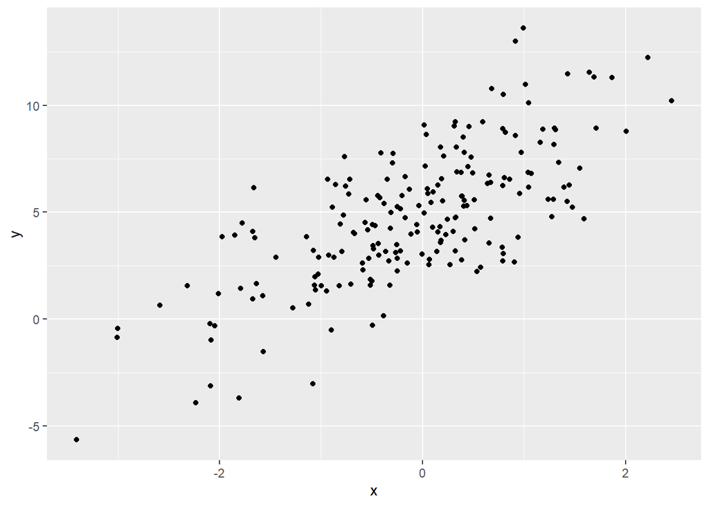

```r
library(ggplot2)

ggplot(df_ex2, aes(x = x, y = y))+
  geom_point()
```

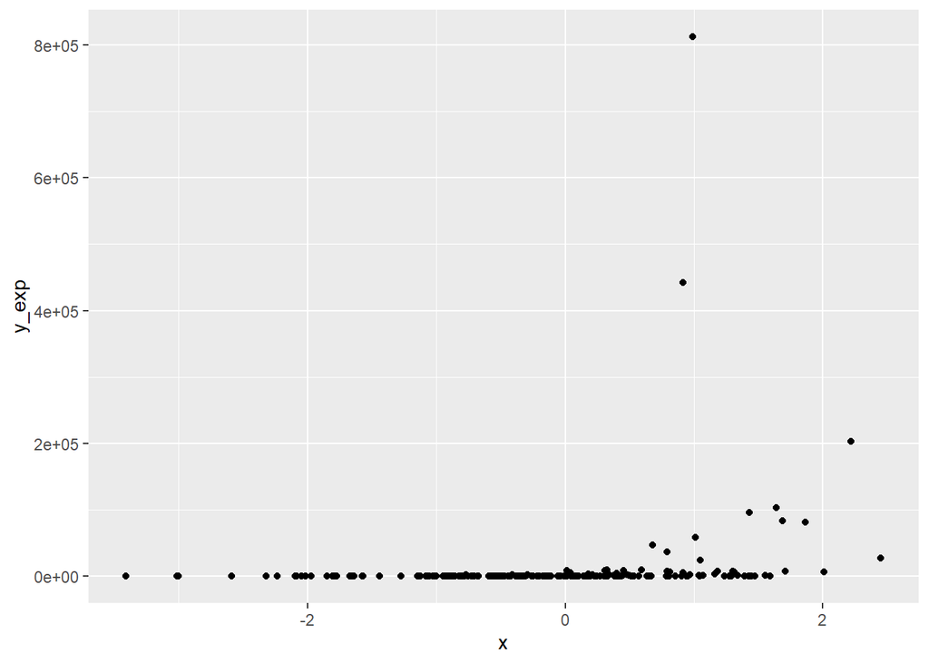

```r
ggplot(df_ex2, aes(x = x, y = y_exp))+
  geom_point()
```

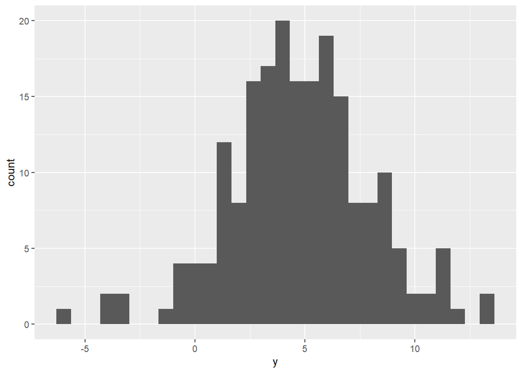

```r
ggplot(df_ex2, aes(x = y))+
    geom_histogram()
```

# Fit a model

Fit a model as a linear regression

```r
mod1_ex2 <- brm(y_exp~x, data = df_ex2, backend = "cmdstanr", cores = 4)
```

[output not shown]

[output cut: 43 more lines]

```
## Chain 4 Iteration: 1100 / 2000 [ 55%]  (Sampling)
## Chain 4 Iteration: 1200 / 2000 [ 60%]  (Sampling)
## Chain 4 Iteration: 1300 / 2000 [ 65%]  (Sampling)
## Chain 4 Iteration: 1400 / 2000 [ 70%]  (Sampling)
## Chain 4 Iteration: 1500 / 2000 [ 75%]  (Sampling)
## Chain 4 Iteration: 1600 / 2000 [ 80%]  (Sampling)
## Chain 4 Iteration: 1700 / 2000 [ 85%]  (Sampling)
## Chain 4 Iteration: 1800 / 2000 [ 90%]  (Sampling)
## Chain 4 Iteration: 1900 / 2000 [ 95%]  (Sampling)
## Chain 4 Iteration: 2000 / 2000 [100%]  (Sampling)
## Chain 4 finished in 0.2 seconds.
##
## All 4 chains finished successfully.
## Mean chain execution time: 0.3 seconds.
## Total execution time: 0.6 seconds.
```

No warnings, but lets check the model summary

```r
summary(mod1_ex2)
```

```
##  Family: gaussian
##   Links: mu = identity; sigma = identity
## Formula: y_exp ~ x
##    Data: df_ex2 (Number of observations: 200)
##   Draws: 4 chains, each with iter = 2000; warmup = 1000; thin = 1;
##          total post-warmup draws = 4000
##
## Population-Level Effects:
##           Estimate Est.Error l-95% CI u-95% CI Rhat Bulk_ESS Tail_ESS
## Intercept  1378.51    636.21   428.85  2371.91 1.00     2024     1226
## x         12953.39   4471.80  4195.28 21808.51 1.00     2696     2155
##
## Family Specific Parameters:
##       Estimate Est.Error l-95% CI u-95% CI Rhat Bulk_ESS Tail_ESS
## sigma 66963.79   3294.42 60911.59 73707.42 1.00     2637     2136
##
## Draws were sampled using sample(hmc). For each parameter, Bulk_ESS
## and Tail_ESS are effective sample size measures, and Rhat is the potential
## scale reduction factor on split chains (at convergence, Rhat = 1).
```

#Launch shiny stan

```r
library(shinystan)
launch_shinystan(mod1_ex2)
```

# Posterior Predictive check

The mechanics of this is very similar to the prior predictive check, but here we wish to see whether our model predicts values similar to what we observed. We have already fit the model, so we will go make a prediction of the $y$, denoted $y_{rep}$ in a lot of the software, using posterior_predict.

```r
yrep1 <- posterior_predict(mod1_ex2)
```

```r
y <- df_ex2$y_exp
yrep1 <- yrep1[1:500,]
```

We can see here that our posterior predicted values are considerably different to the observed, both in shape and also spread.

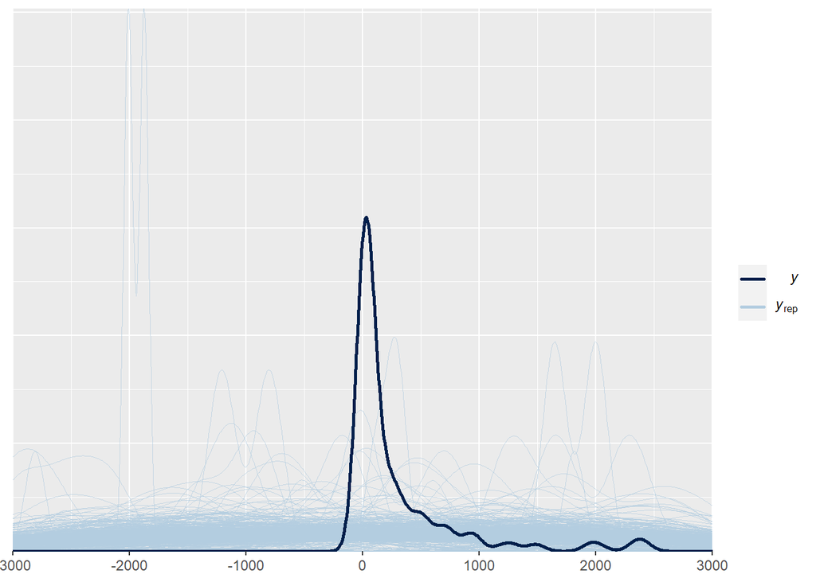

```r
library(bayesplot)
plot_predictive1 <- ppc_dens_overlay(y, yrep1)

plot_predictive1 +xlim(c(-3000,3000))
```

We can also replace this with a test statistic. Here I will use whether the value was less than zero or not.

```r
prop_lessthanzero <- function(x) mean(x < 0)
prop_lessthanzero(y) # check proportion of zeros in y
```

```
## [1] 0
```

This highlights the problem very clearly!

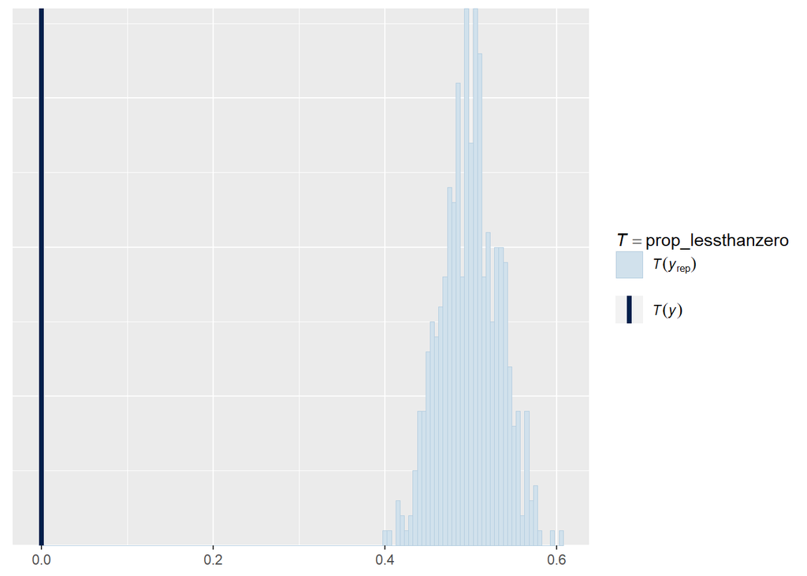

```r
ppc_stat(y, yrep1, stat = "prop_lessthanzero", binwidth = 0.005)
```

I also like to sometimes compare a few iterations of the yreps with y as a scatter plot. There’s no bayesplot version that I am aware of, but it’s fairly easy to code

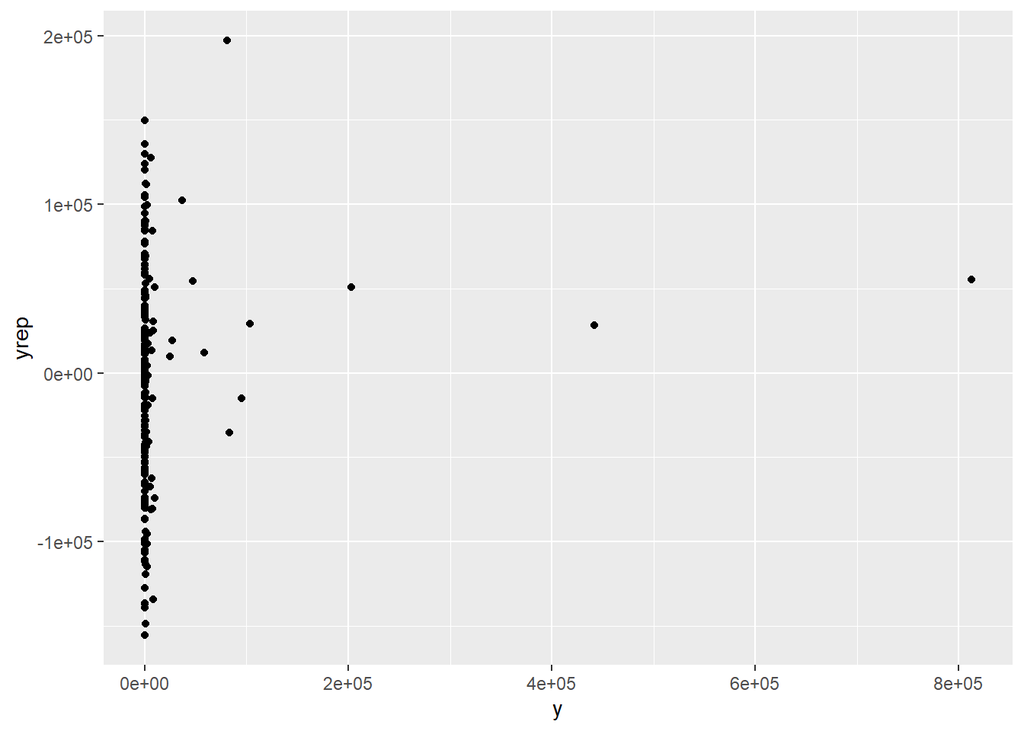

```r
df_pp1 <- data.frame(y = y, yrep = yrep1[1,])

ggplot(df_pp1, aes(x = y, y = yrep))+
  geom_point()
```

Let’s refit the model now but log transform the outcome.

```r
mod2_ex2 <- brm(log(y_exp)~x, data = df_ex2, backend = "cmdstanr", cores = 4)
```

[output not shown]

[output cut: 43 more lines]

```
## Chain 4 Iteration: 1400 / 2000 [ 70%]  (Sampling)
## Chain 4 Iteration: 1500 / 2000 [ 75%]  (Sampling)
## Chain 4 Iteration: 1600 / 2000 [ 80%]  (Sampling)
## Chain 4 Iteration: 1700 / 2000 [ 85%]  (Sampling)
## Chain 4 Iteration: 1800 / 2000 [ 90%]  (Sampling)
## Chain 4 Iteration: 1900 / 2000 [ 95%]  (Sampling)
## Chain 4 Iteration: 2000 / 2000 [100%]  (Sampling)
## Chain 1 finished in 0.1 seconds.
## Chain 2 finished in 0.1 seconds.
## Chain 3 finished in 0.1 seconds.
## Chain 4 finished in 0.1 seconds.
##
## All 4 chains finished successfully.
## Mean chain execution time: 0.1 seconds.
## Total execution time: 0.5 seconds.
```

```r
summary(mod2_ex2)
```

```
##  Family: gaussian
##   Links: mu = identity; sigma = identity
## Formula: log(y_exp) ~ x
##    Data: df_ex2 (Number of observations: 200)
##   Draws: 4 chains, each with iter = 2000; warmup = 1000; thin = 1;
##          total post-warmup draws = 4000
##
## Population-Level Effects:
##           Estimate Est.Error l-95% CI u-95% CI Rhat Bulk_ESS Tail_ESS
## Intercept     5.00      0.16     4.70     5.32 1.00     4001     2739
## x             2.21      0.15     1.91     2.51 1.00     3668     2403
##
## Family Specific Parameters:
##       Estimate Est.Error l-95% CI u-95% CI Rhat Bulk_ESS Tail_ESS
## sigma     2.23      0.11     2.02     2.46 1.00     3729     2894
##
## Draws were sampled using sample(hmc). For each parameter, Bulk_ESS
## and Tail_ESS are effective sample size measures, and Rhat is the potential
## scale reduction factor on split chains (at convergence, Rhat = 1).
```

Posterior predict and create plots

```r
yrep2 <- posterior_predict(mod2_ex2, ndraw = 500)
y2 = log(y)
```

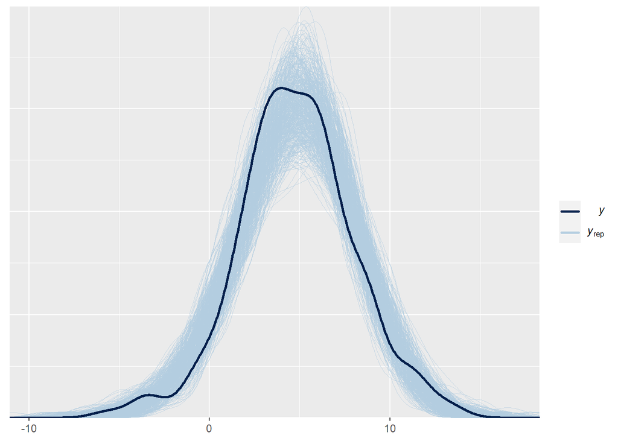

```r
plot_predictive2 <- ppc_dens_overlay(y2, yrep2)

plot_predictive2
```

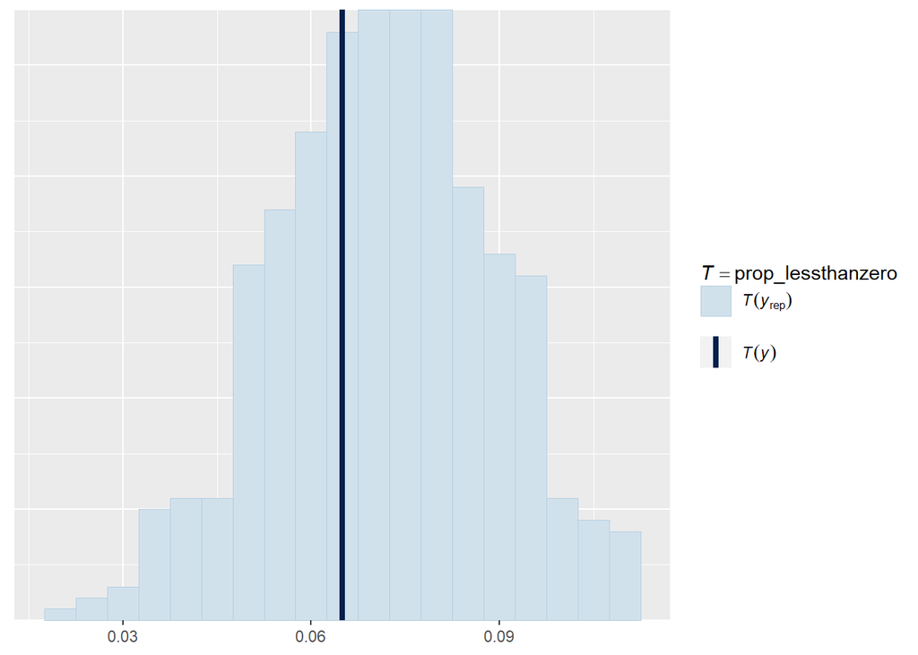

```r
ppc_stat(y2, yrep2, stat = "prop_lessthanzero", binwidth = 0.005)
```

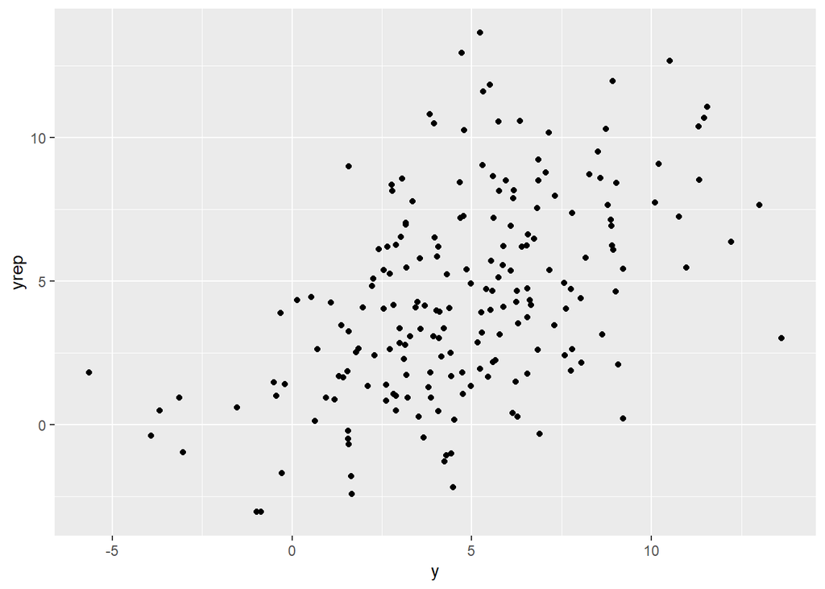

```r
df_pp2 <- data.frame(y = y2, yrep = yrep2[1,])

ggplot(df_pp2, aes(x = y, y = yrep))+
  geom_point()
```